# R Stats Package Exercise

Jerri Schorr

11-19-2019

### Set Up

Stats is a base package, meaning it should already be installed, if it is not or if it needs updated, R will do so when you run `install.packages`.

- We will be using the “cars” data set in R for the following exercises

### Exercise 1

Let’s find the median of data.

- The median is used instead of the mean when the data has a very large spread of data

```r
median(cars$speed) #you can choose any column or data set you would like to put in the function
```

```
[1] 15
```

### Exercise 2

Now let’s find the standard deviation of data.

- Standard Deviation is a measure of spread.

```r
sd(cars$speed)
```

```
[1] 5.287644
```

### Exercise 3

Now let’s find the Inter Quartile Range (IQR) of data.

- The IQR tells you the distance between the 3rd quartile and the 1st quartile

```r
IQR(cars$speed)
```

```
[1] 7
```

### Exercise 4

Next we will fit the data with a Linear Model to see its relationship

- Linear Models show whether data is correlated in a positive direction, negative direction, or if there is no correlation.

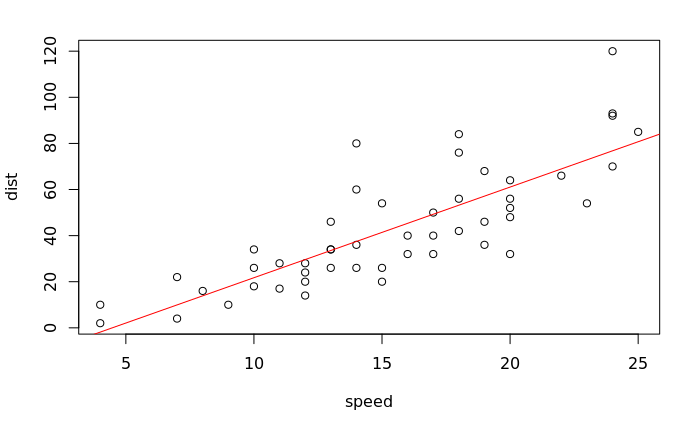